# 중국 성조 분석 2차

## 분석 개요

중국어 지각실험이고, 두글자로 된 중국어 단어를 듣고 첫번째 음절의 성조가 무엇인지 양자택일로 선택하는 실험(1성/3성)이었습니다. 정식 실험 개시는 안했고 예비 실험이라 총 7명의 데이터에요 7(명) * 288(문항) = 2016

### 분석방법 설명

NMDS(Non-metric Multidimensional Scaling)는 비표준적인 거리 척도를 가진 데이터에서 차원 축소를 수행하는 방법입니다. 이를 수학적으로 설명하면 다음과 같습니다.

- 거리 행렬(Distance Matrix): NMDS는 데이터 간의 거리 행렬을 기반으로 작동합니다. 이 거리 행렬은 원래 데이터에서 샘플 간의 거리를 계산하여 만들어집니다.
- 유사도 행렬(Similarity Matrix): 거리 행렬로부터 유사도 행렬을 계산합니다. 이는 각 샘플 쌍의 유사도를 계산하여 만들어진 행렬입니다. 일반적으로는 거리 값이 작을수록 유사도 값이 높아집니다.
- 중심화(Mean Centering): 유사도 행렬에서 각 샘플의 평균 유사도를 계산합니다. 이를 중심화된 유사도 행렬이라고 합니다.
- 고유값 분해(Eigenvalue Decomposition): 중심화된 유사도 행렬을 고유값 분해하여 고유값과 고유벡터를 추출합니다.
- 저차원 공간으로의 변환: 고유값과 고유벡터를 이용하여 저차원 공간으로의 변환을 수행합니다. 이 때, 고유값이 큰 고유벡터부터 차례대로 선택하여 사용하며, 이를 이용하여 저차원 공간에서의 샘플 간의 거리를 계산합니다.
- Stress 값 계산: 변환된 저차원 공간에서의 샘플 간 거리와 원래 거리 행렬 간의 차이를 나타내는 Stress 값이라는 지표를 계산합니다. 이 값이 작을수록 저차원 공간에서의 거리가 원래 거리에 가깝다는 것을 의미합니다.
- 시각화: 변환된 저차원 공간에서의 데이터를 시각화합니다. 일반적으로는 2차원 또는 3차원 공간에 시각화하여 데이터의 구조를 파악합니다.

NMDS는 고차원 데이터를 저차원 공간으로 변환하는 방법으로, PCA와는 달리 비선형적인 구조를 보존하는 것이 가능합니다. 이를 통해, 복잡한 데이터 구조를 간단하게 시각화하거나, 비교 분석 등의 작업에 활용할 수 있습니다.

### 사용변수

- **choice**: 응답 내용입니다. ’1성’은 1, ’3성’은 0으로 코딩해놓았어요
- **onset** : 첫 글자의 두음(b, d, z, f, sh, zh; 초성)
- **vq**: 첫 글자의 발성유형(modal, creaky; 된소리, 거센소리 같은 구분입니다)
- **gender**: 녹음자의 성별(남, 여; 남, 여 두명이 녹음했어요)
- **df1**: 첫 글자(p; preceding)와 두번째 글자(f; following)의 음높이 차이 (p<f, p>f; p<f는 첫번째 글자가 더 낮은 것, p>f는 첫번째 글자가 더 높은 것)
- **df2**: df1의 구체적인 차이값(p에서 f를 뺀 값입니다)
- **group**: vq와 df1의 레벨에 따라서 음성파일을 네 개 그룹으로 나누었습니다 (G1: modal/p<f, G2: modal/p>f, G3: creaky/p<f, G4: creaky/p>f) 그러니까 vq로 보면 G1-G2, G3-G4이 같고, df1으로 보면 G1-G3, G2-G4가 같습니다.
- **F0**: 첫 글자의 음높이
- **rime**: 첫 글자의 운(ao, a; 중성, 종성)

## Library

```r
library(vegan)
```

```r
library(ggplot2)
library(dplyr)
```

## Data Load

```r
set.seed(4)
setwd('/Users/home/Desktop')
china_data = read.csv('/Users/home/Desktop/SNU/results.csv')
head(china_data)
```

```
##   X onset rime     vq F0 gender group df1 df2 choice   RT    pcp
## 1 1     b   ao  modal  7 female    G1 p<f  -2      0 2006 718382
## 2 2     b   ao creaky 14 female    G4 p>f   5      1 1745 718382
## 3 3     b   ao creaky  4 female    G3 p<f  -5      0 1878 718382
## 4 4     b   ao creaky  8 female    G3 p<f  -1      0 1547 718382
## 5 5     d   ao  modal 11 female    G2 p>f   2      0 1817 718382
## 6 6     d   ao  modal 15 female    G2 p>f   6      1 1721 718382
```

## Data Handling

### - Missing treat

```r
# 2016th data is missing
china_data[2016,c('pcp')] = '725115'
china_data[2016,]
```

```
##         X onset rime     vq F0 gender group df1 df2 choice   RT    pcp
## 2016 2016    zh   ao creaky  5   male    G4 p>f   6      1 1414 725115
```

### - PCP Label change

- from [“718382” “719740” “719762” “720547” “720828” “723496” “725115”] to [“1”,“2”,…,“7”]

```r
china_data$pcp = as.integer(as.factor(china_data$pcp))
```

### - Feature Select

```r
df = china_data[,c('group','pcp','choice','onset','vq','gender','df1','df2','rime','F0')]

df$pcp = as.factor(df$pcp)
df$group = as.factor(df$group)
df$onset = as.factor(df$onset)
df$vq = as.factor(df$vq)
df$gender = as.factor(df$gender)
df$df1 = as.factor(df$df1)
df$rime = as.factor(df$rime)

head(df)
```

```
##   group pcp choice onset     vq gender df1 df2 rime F0
## 1    G1   1      0     b  modal female p<f  -2   ao  7
## 2    G4   1      1     b creaky female p>f   5   ao 14
## 3    G3   1      0     b creaky female p<f  -5   ao  4
## 4    G3   1      0     b creaky female p<f  -1   ao  8
## 5    G2   1      0     d  modal female p>f   2   ao 11
## 6    G2   1      1     d  modal female p>f   6   ao 15
```

## Remove pcp and group by

- pcp remove and grouping (group,choice,onset,vq,gender,df1,rime)
- min-max scaling on contiuous variable about mean (df2,F0)

```r
grouped_df =
  df %>%
  group_by(group,choice,onset,vq,gender,df1,rime) %>%
  summarise(cnt=n(),df2 = mean(df2),F0= mean(F0)) %>%
  ungroup()
```

```
## 'df1'. You can override using the `.groups` argument.
```

```r
grouped_df$cnt = (grouped_df$cnt - min(grouped_df$cnt)) / (max(grouped_df$cnt) - min(grouped_df$cnt))
grouped_df$df2 = (grouped_df$df2 - min(grouped_df$df2)) / (max(grouped_df$df2) - min(grouped_df$df2))
grouped_df$F0 = (grouped_df$F0 - min(grouped_df$F0)) / (max(grouped_df$F0) - min(grouped_df$F0))

grouped_df = as.data.frame(grouped_df)
head(grouped_df)
```

```
##   group choice onset    vq gender df1 rime       cnt       df2        F0
## 1    G1      0     b modal female p<f   ao 0.9512195 0.2207006 0.5880471
## 2    G1      0     b modal   male p<f   ao 1.0000000 0.2229299 0.1178451
## 3    G1      0     d modal female p<f   ao 0.9512195 0.2251592 0.5904040
## 4    G1      0     d modal   male p<f   ao 1.0000000 0.2229299 0.1178451
## 5    G1      0     f modal female p<f    a 0.9512195 0.2162420 0.5856902
## 6    G1      0     f modal   male p<f    a 1.0000000 0.2229299 0.1178451
```

### - Matrix for Dummy Variable

- Convert categorical varaible to Dummy (0,1)
- Select Variables in model.matrix
- df2&F0&**cnt** are continuous Variables

```r
model_matrix = cbind(
  model.matrix(~choice+onset+vq+gender+df1+rime-1,data=grouped_df),
    avg_df2=grouped_df$df2,
    avg_F0=grouped_df$F0,
    cnt = grouped_df$cnt
  )

head(model_matrix)
```

```
##   choice onsetb onsetd onsetf onsetsh onsetz onsetzh vqmodal gendermale df1p>f
## 1      0      1      0      0       0      0       0       1          0      0
## 2      0      1      0      0       0      0       0       1          1      0
## 3      0      0      1      0       0      0       0       1          0      0
## 4      0      0      1      0       0      0       0       1          1      0
## 5      0      0      0      1       0      0       0       1          0      0
## 6      0      0      0      1       0      0       0       1          1      0
##   rimeao   avg_df2    avg_F0       cnt
## 1      1 0.2207006 0.5880471 0.9512195
## 2      1 0.2229299 0.1178451 1.0000000
## 3      1 0.2251592 0.5904040 0.9512195
## 4      1 0.2229299 0.1178451 1.0000000
## 5      0 0.2162420 0.5856902 0.9512195
## 6      0 0.2229299 0.1178451 1.0000000
```

### Similarity Matrix

- matrix size = n(n-1)/2
- The ‘binary=FALSE’ option needs to be used with the ‘vegdist’ function for continuous variables

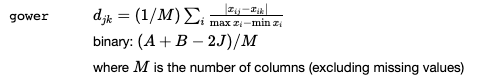

gower-distance

```r
d <- vegdist(model_matrix,binary=FALSE,method='gower')
```

### Non-metric Multidimensional Scaling(NMDS)

- Rank-ordered Method (Non-parametric)
- **If you do not set a seed, the result can vary each time you run the function (because the starting point for calculating the distance can be different each time).**

```r
res <- monoMDS(d, k = 2)
res_df <- data.frame(Group =grouped_df$group,res$points)
head(res_df)
```

```
##   Group       MDS1       MDS2
## 1    G1 -0.6578223  0.7177936
## 2    G1 -1.1347639  0.3279761
## 3    G1 -0.6830220  0.7491495
## 4    G1 -1.1210796  0.3677911
## 5    G1 -0.8107302 -0.5149636
## 6    G1 -1.0898362 -0.7275263
```

### DataFrame For Visualization

- All variables

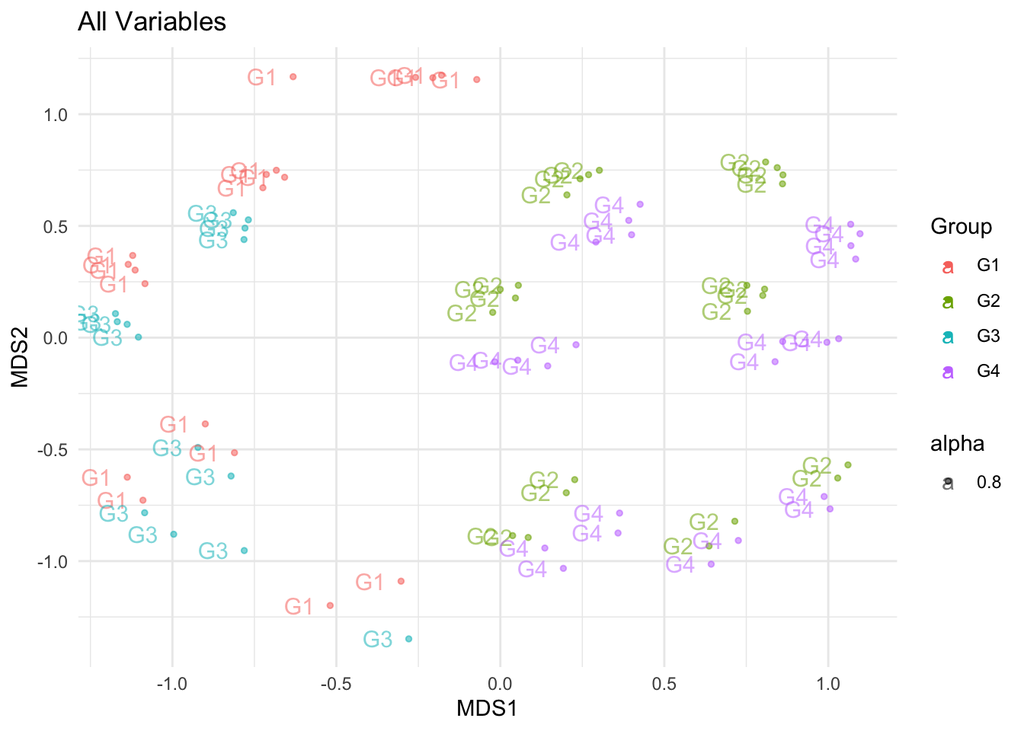

```r
ggplot(res_df, aes(x = MDS1, y = MDS2, color = Group, alpha = 0.8)) +
  geom_point(size = 1) +
  geom_text(aes(label = Group), hjust = 1.5, size = 4) +
  ggtitle('All Variables') +
  theme_minimal()
```

### The impact of column changes on the NMDS results

- Remove the following columns: **‘onset’, ‘vq’, ‘gender’, ‘df1’, ‘df2’, ‘rime’, and ‘F0’**. Note that the **‘choice’,‘cnt’** columns should always be retained

#### Reomve onset

- **onset** : 첫 글자의 두음(b, d, z, f, sh, zh; 초성)
- categorical varaible

```r
# Data Handling


grouped_df =
  df %>%
  group_by(group,choice,vq,gender,df1,rime) %>%
  summarise(cnt=n(),df2 = mean(df2),F0= mean(F0)) %>%
  ungroup()
```

```
## You can override using the `.groups` argument.
```

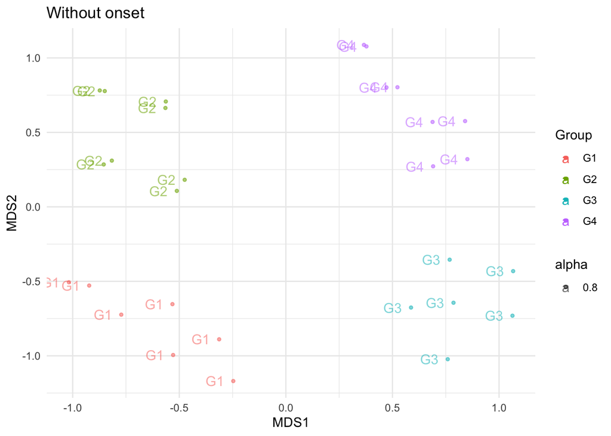

```r
grouped_df$cnt = (grouped_df$cnt - min(grouped_df$cnt)) / (max(grouped_df$cnt) - min(grouped_df$cnt))
grouped_df$df2 = (grouped_df$df2 - min(grouped_df$df2)) / (max(grouped_df$df2) - min(grouped_df$df2))
grouped_df$F0 = (grouped_df$F0 - min(grouped_df$F0)) / (max(grouped_df$F0) - min(grouped_df$F0))

grouped_df = as.data.frame(grouped_df)

# Model matrix
model_matrix = cbind(
  model.matrix(~choice+vq+gender+df1+rime-1,data=grouped_df),
    avg_df2=grouped_df$df2,
    avg_F0=grouped_df$F0,
    cnt = grouped_df$cnt
  )

# 유사도 행렬 계산

d <- vegdist(model_matrix,binary=FALSE,method='gower')

# NMDS 실행

res <- monoMDS(d, k = 2)

# 각 참가자의 ID와 그룹 정보를 포함하는 데이터프레임 생성

res_df <- data.frame(Group =grouped_df$group,res$points)

# 시각화

# Group

ggplot(res_df, aes(x = MDS1, y = MDS2, color = Group, alpha = 0.8)) +
  geom_point(size = 1) +
  geom_text(aes(label = Group), hjust = 1.5, size = 4) +
  ggtitle('Without onset') +
  theme_minimal()
```

#### Reomve vq

- **vq**: 첫 글자의 발성유형(modal, creaky; 된소리, 거센소리 같은 구분입니다)
- categorical varaible

```r
# Data Handling


grouped_df =
  df %>%
  group_by(group,choice,onset,gender,df1,rime) %>%
  summarise(cnt=n(),df2 = mean(df2),F0= mean(F0)) %>%
  ungroup()
```

```
## 'df1'. You can override using the `.groups` argument.
```

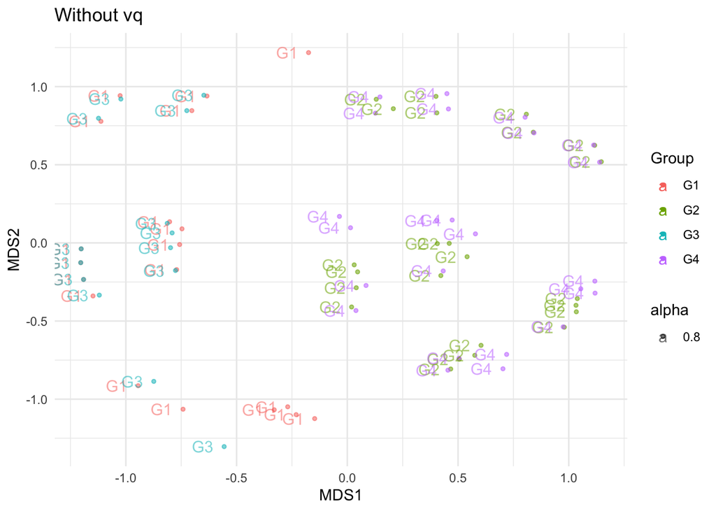

```r
grouped_df$cnt = (grouped_df$cnt - min(grouped_df$cnt)) / (max(grouped_df$cnt) - min(grouped_df$cnt))
grouped_df$df2 = (grouped_df$df2 - min(grouped_df$df2)) / (max(grouped_df$df2) - min(grouped_df$df2))
grouped_df$F0 = (grouped_df$F0 - min(grouped_df$F0)) / (max(grouped_df$F0) - min(grouped_df$F0))

grouped_df = as.data.frame(grouped_df)

# Model matrix
model_matrix = cbind(
  model.matrix(~choice+onset+gender+df1+rime-1,data=grouped_df),
    avg_df2=grouped_df$df2,
    avg_F0=grouped_df$F0,
    cnt = grouped_df$cnt
  )

# 유사도 행렬 계산

d <- vegdist(model_matrix,binary=FALSE,method='gower')

# NMDS 실행

res <- monoMDS(d, k = 2)

# 각 참가자의 ID와 그룹 정보를 포함하는 데이터프레임 생성

res_df <- data.frame(Group =grouped_df$group,res$points)

# 시각화

# Group

ggplot(res_df, aes(x = MDS1, y = MDS2, color = Group, alpha = 0.8)) +
  geom_point(size = 1) +
  geom_text(aes(label = Group), hjust = 1.5, size = 4) +
  ggtitle('Without vq') +
  theme_minimal()
```

#### Reomve gender

- **gender**: 녹음자의 성별(남, 여; 남, 여 두명이 녹음했어요)
- categorical varaible

```r
# Data Handling


grouped_df =
  df %>%
  group_by(group,choice,onset,vq,df1,rime) %>%
  summarise(cnt=n(),df2 = mean(df2),F0= mean(F0)) %>%
  ungroup()
```

```
## You can override using the `.groups` argument.
```

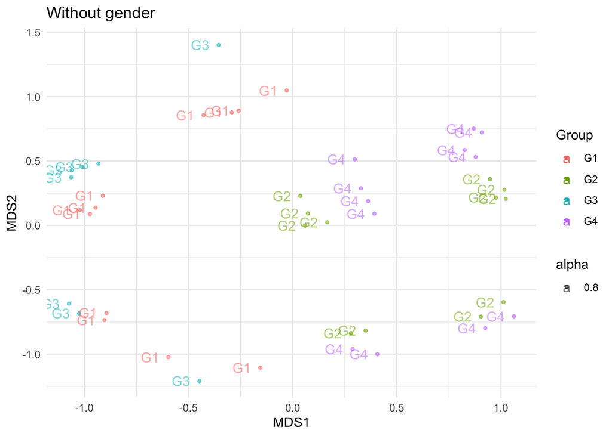

```r
grouped_df$cnt = (grouped_df$cnt - min(grouped_df$cnt)) / (max(grouped_df$cnt) - min(grouped_df$cnt))
grouped_df$df2 = (grouped_df$df2 - min(grouped_df$df2)) / (max(grouped_df$df2) - min(grouped_df$df2))
grouped_df$F0 = (grouped_df$F0 - min(grouped_df$F0)) / (max(grouped_df$F0) - min(grouped_df$F0))

grouped_df = as.data.frame(grouped_df)

# Model matrix
model_matrix = cbind(
  model.matrix(~choice+onset+vq+df1+rime-1,data=grouped_df),
    avg_df2=grouped_df$df2,
    avg_F0=grouped_df$F0,
    cnt = grouped_df$cnt
  )

# 유사도 행렬 계산

d <- vegdist(model_matrix,binary=FALSE,method='gower')

# NMDS 실행

res <- monoMDS(d, k = 2)

# 각 참가자의 ID와 그룹 정보를 포함하는 데이터프레임 생성

res_df <- data.frame(Group =grouped_df$group,res$points)

# 시각화

# Group

ggplot(res_df, aes(x = MDS1, y = MDS2, color = Group, alpha = 0.8)) +
  geom_point(size = 1) +
  geom_text(aes(label = Group), hjust = 1.5, size = 4) +
  ggtitle('Without gender') +
  theme_minimal()
```

#### Reomve df1

- **df1**: 첫 글자(p; preceding)와 두번째 글자(f; following)의 음높이 차이 (p<f, p>f; p<f는 첫번째 글자가 더 낮은 것, p>f는 첫번째 글자가 더 높은 것)
- categorical varaible

```r
# Data Handling


grouped_df =
  df %>%
  group_by(group,choice,onset,vq,gender,rime) %>%
  summarise(cnt=n(),df2 = mean(df2),F0= mean(F0)) %>%
  ungroup()
```

```
## You can override using the `.groups` argument.
```

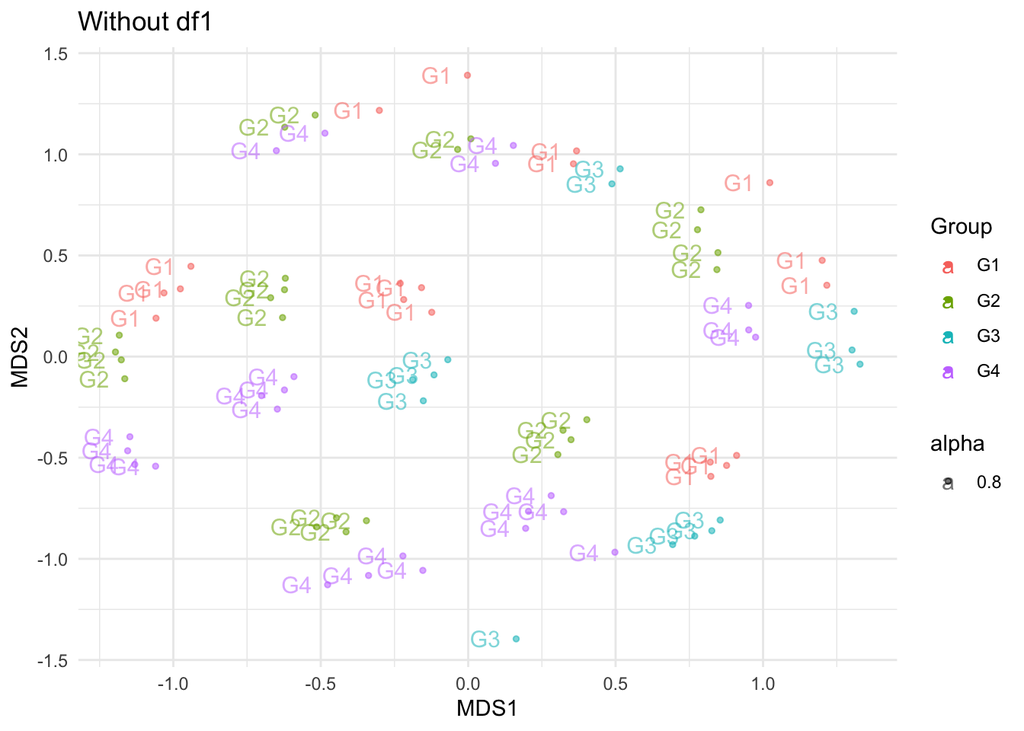

```r
grouped_df$cnt = (grouped_df$cnt - min(grouped_df$cnt)) / (max(grouped_df$cnt) - min(grouped_df$cnt))
grouped_df$df2 = (grouped_df$df2 - min(grouped_df$df2)) / (max(grouped_df$df2) - min(grouped_df$df2))
grouped_df$F0 = (grouped_df$F0 - min(grouped_df$F0)) / (max(grouped_df$F0) - min(grouped_df$F0))

grouped_df = as.data.frame(grouped_df)

# Model matrix
model_matrix = cbind(
  model.matrix(~choice+onset+vq+gender+rime-1,data=grouped_df),
    avg_df2=grouped_df$df2,
    avg_F0=grouped_df$F0,
    cnt = grouped_df$cnt
  )

# 유사도 행렬 계산

d <- vegdist(model_matrix,binary=FALSE,method='gower')

# NMDS 실행

res <- monoMDS(d, k = 2)

# 각 참가자의 ID와 그룹 정보를 포함하는 데이터프레임 생성

res_df <- data.frame(Group =grouped_df$group,res$points)

# 시각화

# Group

ggplot(res_df, aes(x = MDS1, y = MDS2, color = Group, alpha = 0.8)) +
  geom_point(size = 1) +
  geom_text(aes(label = Group), hjust = 1.5, size = 4) +
  ggtitle('Without df1') +
  theme_minimal()
```

#### Reomve rime

- **rime**: 첫 글자의 운(ao, a; 중성, 종성)
- categorical varaible

```r
# Data Handling

grouped_df =
  df %>%
  group_by(group,choice,onset,vq,gender,df1) %>%
  summarise(cnt=n(),df2 = mean(df2),F0= mean(F0)) %>%
  ungroup()
```

```
## You can override using the `.groups` argument.
```

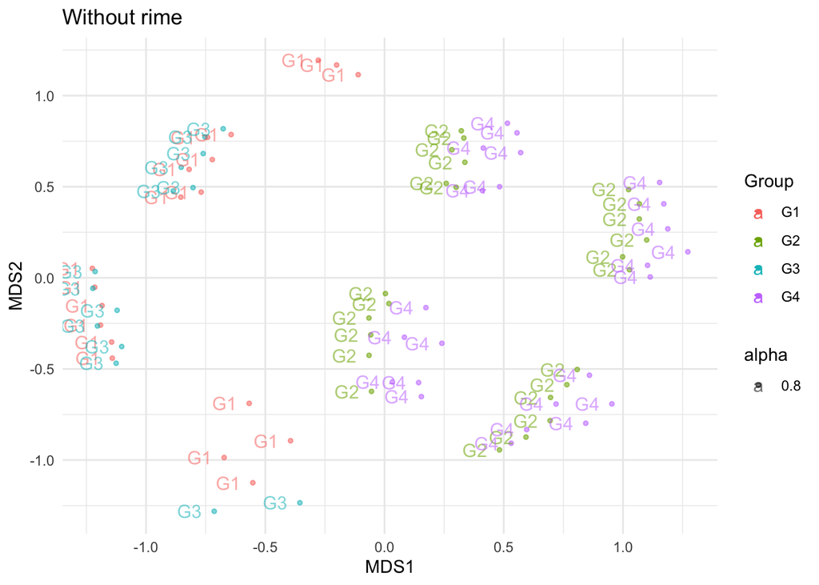

```r
grouped_df$cnt = (grouped_df$cnt - min(grouped_df$cnt)) / (max(grouped_df$cnt) - min(grouped_df$cnt))
grouped_df$df2 = (grouped_df$df2 - min(grouped_df$df2)) / (max(grouped_df$df2) - min(grouped_df$df2))
grouped_df$F0 = (grouped_df$F0 - min(grouped_df$F0)) / (max(grouped_df$F0) - min(grouped_df$F0))

grouped_df = as.data.frame(grouped_df)

# Model matrix
model_matrix = cbind(
  model.matrix(~choice+onset+vq+gender+df1-1,data=grouped_df),
    avg_df2=grouped_df$df2,
    avg_F0=grouped_df$F0,
    cnt = grouped_df$cnt
  )

# 유사도 행렬 계산

d <- vegdist(model_matrix,binary=FALSE,method='gower')

# NMDS 실행

res <- monoMDS(d, k = 2)

# 각 참가자의 ID와 그룹 정보를 포함하는 데이터프레임 생성

res_df <- data.frame(Group =grouped_df$group,res$points)

# 시각화

# Group

ggplot(res_df, aes(x = MDS1, y = MDS2, color = Group, alpha = 0.8)) +
  geom_point(size = 1) +
  geom_text(aes(label = Group), hjust = 1.5, size = 4) +
  ggtitle('Without rime') +
  theme_minimal()
```

#### Reomve df2

- **df2**: df1의 구체적인 차이값의 평균의 MIN-MAX 스케일링
- continous vairable

```r
# Data Handling


grouped_df =
  df %>%
  group_by(group,choice,onset,vq,gender,df1,rime) %>%
  summarise(
    cnt=n(),
    F0= mean(F0)) %>%
  ungroup()
```

```
## 'df1'. You can override using the `.groups` argument.
```

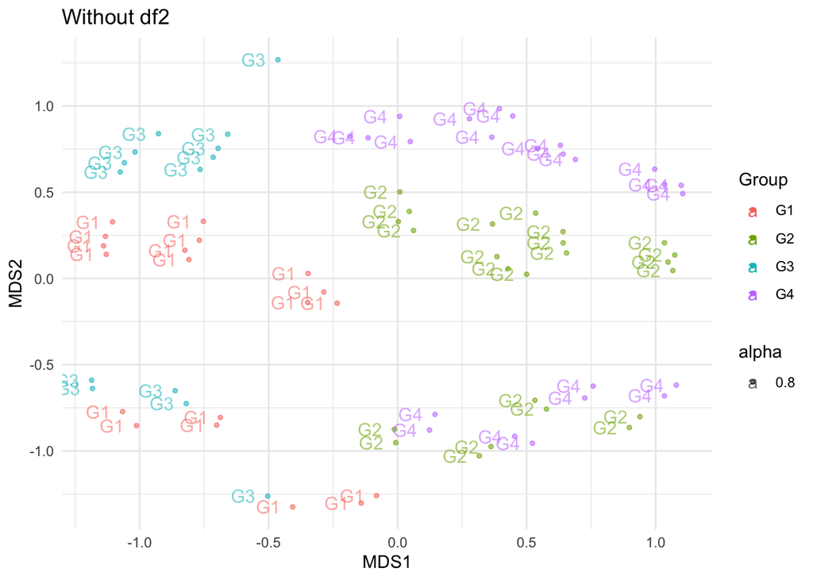

```r
grouped_df$cnt = (grouped_df$cnt - min(grouped_df$cnt)) / (max(grouped_df$cnt) - min(grouped_df$cnt))
grouped_df$F0 = (grouped_df$F0 - min(grouped_df$F0)) / (max(grouped_df$F0) - min(grouped_df$F0))

grouped_df = as.data.frame(grouped_df)

# Model matrix
model_matrix = cbind(
  model.matrix(~choice+onset+vq+gender+df1+rime-1,data=grouped_df),
    avg_F0=grouped_df$F0,
    cnt = grouped_df$cnt
  )

# 유사도 행렬 계산

d <- vegdist(model_matrix,binary=FALSE,method='gower')

# NMDS 실행

res <- monoMDS(d, k = 2)

# 각 참가자의 ID와 그룹 정보를 포함하는 데이터프레임 생성

res_df <- data.frame(Group =grouped_df$group,res$points)

# 시각화

ggplot(res_df, aes(x = MDS1, y = MDS2, color = Group, alpha = 0.8)) +
  geom_point(size = 1) +
  geom_text(aes(label = Group), hjust = 1.5, size = 4) +
  ggtitle('Without df2') +
  theme_minimal()
```

#### Reomve F0

- **F0**: 첫 글자의 음높이 평균의 MIN-MAX 스케일링
- continous variable

```r
# Data Handling


grouped_df =
  df %>%
  group_by(group,choice,onset,vq,gender,df1,rime) %>%
  summarise(
    cnt=n(),
    df2 = mean(df2)
    ) %>%
  ungroup()
```

```
## 'df1'. You can override using the `.groups` argument.
```

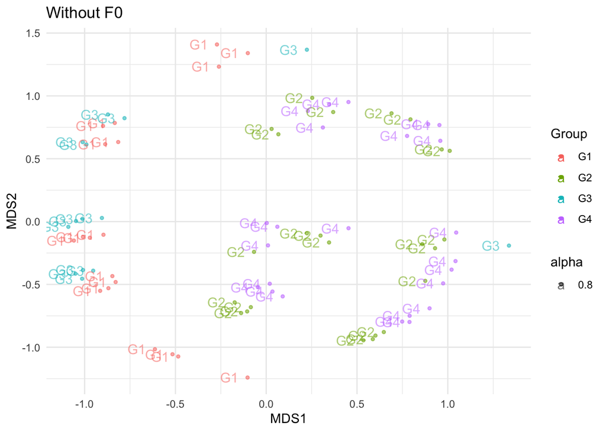

```r
grouped_df$cnt = (grouped_df$cnt - min(grouped_df$cnt)) / (max(grouped_df$cnt) - min(grouped_df$cnt))
grouped_df$df2 = (grouped_df$df2 - min(grouped_df$df2)) / (max(grouped_df$df2) - min(grouped_df$df2))

grouped_df = as.data.frame(grouped_df)

# Model matrix
model_matrix = cbind(
  model.matrix(~choice+onset+vq+gender+df1+rime-1,data=grouped_df),
    avg_df2=grouped_df$df2,
    cnt = grouped_df$cnt
  )

# 유사도 행렬 계산

d <- vegdist(model_matrix,binary=FALSE,method='gower')

# NMDS 실행

res <- monoMDS(d, k = 2)

# 각 참가자의 ID와 그룹 정보를 포함하는 데이터프레임 생성

res_df <- data.frame(Group =grouped_df$group,res$points)

# 시각화

ggplot(res_df, aes(x = MDS1, y = MDS2, color = Group, alpha = 0.8)) +
  geom_point(size = 1) +
  geom_text(aes(label = Group), hjust = 1.5, size = 4) +
  ggtitle('Without F0') +
  theme_minimal()
```

## Conclusion

- 각 변수 제거시에 나타나는 효과를 직접 적으시면 될 것 같습니다. (제 주관적인 핵석은 배제토록 하겠습니다.)
- 다만 변수가 제거 됐을 따 각 그룹끼리 어떻게 묶이는지, 어떤 방향으로 이동하는지에 해단 방향으로 작성하시면 좋을 것 같습니다.